# Colorado

Maidenhaven

2023-04-17

# 1 Abstract

Colorado is located in the middle of the United States, the state has a population of less than 5 million, but the highest percentage of higher education in the country. It is a national leader in high-technology industries and the new economy, including the renewable energy business, which has become a hot topic in recent years. As Colorado’s population and economy continue to grow, there is an increasing demand for energy to power homes, businesses, and industries. However, this demand for energy must be balanced with the need for conservation and sustainability to ensure that Colorado’s natural resources and environment are protected for future generations. This challenge requires a multifaceted approach that addresses the various factors contributing to energy demand and consumption in the state.

# 2 Introduction

The U.S. energy landscape is undergoing rapid change and development. Currently, the major sources of energy in the United States are fossil fuels such as oil, natural gas, and coal, but the share of renewable energy sources is increasing. Colorado’s natural gas resources are abundant, making natural gas one of the state’s primary sources of energy. The state is also one of the coal-producing states in the U.S., but is gradually reducing its reliance on coal as the global energy transition and environmental awareness increase. Colorado is at the forefront of the nation when it comes to renewable energy. In this report, we will explore potential solutions and strategies that Colorado can implement to address the challenge of balancing energy demands for its growing population and economy with the need for conservation and sustainability. We will mainly focusing on renewable energy and economic development. Since 2010, Colorado’s renewable electricity net generation has more than tripled and accounted for 35% of the state’s total generation in 2021. Wind power accounted for almost four-fifth of the state’s renewable electricity generation in 2021. Going forward, Colorado’s energy trends will continue to move in a clean and sustainable direction. The state will continue to promote the use of solar, wind and other renewable energy sources to achieve more environmentally and economically sustainable energy development.

# 3 Exploratory Data Analysis

## 3.1 Total Energy Consumption in Colorado

[interactive chart not shown]

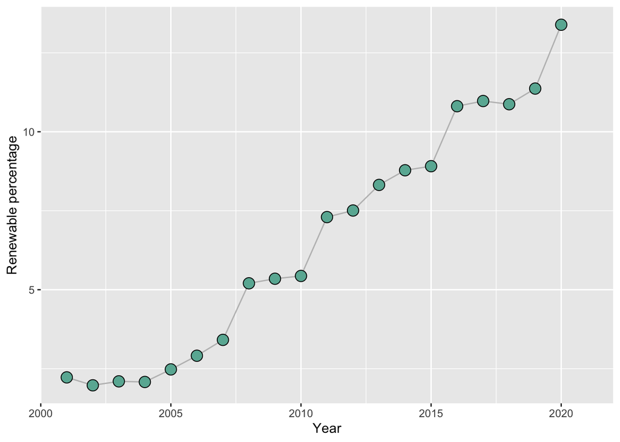

Based on the overall energy consumption chart of various types in Colorado from 2001 to 2021, it can be observed that natural gas, petroleum, and coal still occupy the top three positions in total energy consumption. Among them, the consumption of natural gas and petroleum has remained relatively stable between 400,000 and 500,000 during this period, while coal consumption has slowly declined from 400,000 to 200,000. Meanwhile, the consumption of new energy sources has shown a slow but steady upward trend. It indicates that despite the increase in new energy consumption, traditional energy sources such as natural gas, petroleum, and coal still dominate Colorado’s overall energy consumption landscape. The slow decline in coal consumption may be attributed to the shift towards cleaner energy sources due to environmental concerns. Furthermore, the relatively stable consumption of natural gas and petroleum indicates their continued importance in meeting the energy needs of the state. Overall, from the chart above we can know that Colorado’s energy consumption is still largely dependent on traditional energy sources, with new energy sources gradually increasing in importance. This trend highlights the need for continued efforts to develop and promote renewable energy technologies in the state to achieve a more sustainable and diversified energy mix. Renewable percentage increased dramatically from 2005 till now.

## 3.2 Wind and Solar Total Consumption and Production in Colorado

[interactive chart not shown]

As we can see from the graph above, Colorado’s wind and solar energy consumption has grown rapidly since 2005. Wind energy, in particular, has grown exponentially.

[interactive chart not shown]

As we can see from the plot above, the production of wind and solar energy grow rapidly since 2005, especially for wind energy. This may due to the Colorado government enacted the Renewable Energy Standard in 2004, which requires electric utilities to increase their use of renewable energy to 20 percent by 2020. This policy has inspired energy companies and others to invest and grow in renewable energy sources such as solar and wind.

## 3.3 Net electricity generation from renewable source in Colorado

[interactive chart not shown]

From 2010 to 2020, net generation from wind energy in Colorado increased from around 200 thousand MWh to 1,800 thousand MWh, while net generation from solar energy fluctuated between 0 and 200 thousand MWh before increasing gradually. The chart shows that the net generation from wind energy has experienced a significant increase from 2010 to 2020, while the net generation from solar energy has remained relatively low and unstable until the mid-2010s. After 2015, the net generation from solar energy started to increase gradually, but still remained much lower than that of wind energy. Overall, the chart suggests that wind energy has been the dominant renewable energy source in Colorado over the past decade, while solar energy has only started to gain traction in recent years. This trend may continue in the future as wind energy technology continues to improve and policy support for renewable energy sources remains strong.

## 3.4 Population and Population Growth in Colorado

|  | DATE | COPOP | Pct Change |
| --- | --- | --- | --- |
| 1 | 2001-01-01 | 4425.687 | 0.0957 |
| 2 | 2001-02-01 | 4431.08025 | 0.12171411248984 |
| 3 | 2001-03-01 | 4436.4735 | 0.121566149330095 |
| 4 | 2001-04-01 | 4441.86675 | 0.121418545479782 |
| 5 | 2001-05-01 | 4447.26 | 0.121271299631685 |
| 6 | 2001-06-01 | 4452.65325 | 0.121124410484919 |
| 7 | 2001-07-01 | 4458.0465 | 0.120977876744894 |
| 8 | 2001-08-01 | 4463.43975 | 0.12083169712326 |
| 9 | 2001-09-01 | 4468.833 | 0.120685870337963 |
| 10 | 2001-10-01 | 4474.22625 | 0.120540395113012 |

[output cut: 255 more lines]

We estimated the population missing values of each month using the method of averaging and the annual population data, then we got the above data frame.

## 3.5 Natural Gas in dfferent sectors in Colorado

[interactive chart not shown]

Based on the plot of natural gas usage in different department in Colorado from June 2014 to January 2017, it can be seen that “correction gas” and “humanservice” are the top two consumers of natural gas during this period, with both showing clear seasonal trends. Specifically, the natural gas consumption reaches its peak in January of each year, with a consumption level of up to 90,000 to 100,000. “Correction gas” is likely to be used for calibrating or correcting gas measurement instruments, while “humanservice” refers to the natural gas consumption in various human services, such as hospitals or nursing homes. The peak consumption in January may be attributed to the cold weather and the increased demand for heating during the winter months. Overall, the plot suggests that natural gas consumption in Colorado is largely driven by seasonal factors and specific industries or services.

## 3.6 Natural gas price in Colorado

[interactive chart not shown]

The plot above, suggests that natural gas prices in Colorado vary significantly depending on the sector and usage. Residential customers pay significantly more for natural gas than industrial customers, while commercial customers pay a moderate price compared to the other two sectors. These price differences reflect the different demands and costs associated with delivering natural gas to different types of customers. Residential customers typically require smaller amounts of natural gas, and the cost of delivery to individual households is higher. Industrial customers, on the other hand, require large amounts of natural gas and are often located close to distribution pipelines, which reduces the cost of delivery. As a result, we can see that there is a pressing need to reduce the cost of home energy use to meet the rising energy demand.

[interactive chart not shown]

## 3.7 Natural Gas Total Consumption and Underground Storage in Colorado

[interactive chart not shown]

## 3.8 Electricity Generation in Colorado

[interactive chart not shown]

## 3.9 Unemployment Rate in Colorado

[interactive chart not shown]

Based on the graph showing the unemployment rate in Colorado from 2000 to 2020, it is clear that there were two sharp increases in the unemployment rate in 2007 and 2019. However, between 2009 and 2019, the unemployment rate steadily declined.The first sharp increase in unemployment occurred in 2007, which coincided with the onset of the Great Recession. This economic downturn had a significant impact on the labor market in Colorado, causing many businesses to close and leading to a surge in unemployment. The second sharp increase in unemployment occurred in 2019, which was likely due to the COVID-19 pandemic and its resulting economic fallout. The steady decline in unemployment from 2009 to 2019 can be attributed to several factors, including the state’s growing economy, the emergence of new industries, and the expansion of job training programs. During this period, Colorado’s unemployment rate consistently remained below the national average, indicating that the state’s economy was relatively stable.

## 3.10 Gasoline Price in Colorado

[interactive chart not shown]

Based on the gasoline price plot for Colorado from 2000 to 2020, we can observe a steady increase from 2002 to 2008, with the price rising from 1.11 to 4. From 2010 to 2020, the price remained relatively stable, fluctuating between 2 and 4. However, starting from 2020, there was a rapid increase in price, with the cost of regular gas exceeding 5 for the first time. This trend suggests that Colorado’s economy is heavily reliant on the oil and gas industry, as demonstrated by the significant impact of oil prices on the state’s overall economic performance. Moreover, the recent surge in gasoline prices highlights the vulnerability of Colorado’s economy to external shocks, such as changes in global oil demand and supply dynamics. Therefore, Colorado urgently needs to improve its current energy mix and diversify its economy as a way to deal with the uncertainty that may arise in the future.

## 3.11 Coal and Natural

Coal and natural gas consumption still account for a significant portion of energy consumption, and we still need to consider the economic impact brought by the consumption of these two energy sources.

# 4 Final Data Prepare

Based on the EDA, we selected appropriate data and integrated it, including electricity generated from wind, electricity generated from solar, population, unemployment rate, wages, etc. We will perform machine learning based on the final data. Our final data has 265 observations and 21 variables.

|  | Unemployment_rate | gas_price.cityGatePrice | gas_price.residentialPrice | gas_price.commercialPrice | gas_price.industrialPrice | gas_price.electricPowerConsumersPrice | Elect_from_Wind | Elect_from_Solar | Population | POP_Increased_Pct | Renewable_Percentage_elect | regularGasolineprice | midgradeGasolinePrice | premiumGasolinePrice | Gas_cons_commercial | Gas_cons_residential | Gas_cons_industry | Wages | coal_cons_com | coal_cons_ind | coal_cons_electp |
| --- | --- | --- | --- | --- | --- | --- | --- | --- | --- | --- | --- | --- | --- | --- | --- | --- | --- | --- | --- | --- | --- |
| 1 | 3 | 6.89 | 7.03 | 6.94 | 9.36 | 0 | 4.158 | 0 | 4425.687 | 0.0957 | 0.100278720821678 | 1.434 | 1.554 | 1.662 | 11551 | 26955 | 10469 | 90.421516 | 462.899 | 7981.484 | 88394.988 |
| 2 | 3.1 | 4.97 | 8.54 | 8.23 | 10.07 | 0 | 2.441 | 0 | 4431.08025 | 0.12171411248984 | 0.0647636432136139 | 1.47 | 1.5825 | 1.69 | 10333 | 25045 | 10226 | 90.17372933 | 367.404 | 7958.195 | 75401.218 |
| 3 | 3.2 | 4.75 | 8.96 | 8.47 | 10.38 | 0 | 2.074 | 0 | 4436.4735 | 0.121566149330095 | 0.0540072943699609 | 1.43 | 1.5475 | 1.6525 | 7921 | 19871 | 9361 | 89.92594267 | 336.243 | 8202.346 | 77919.041 |
| 4 | 3.1 | 5.21 | 9.46 | 8.99 | 7.4 | 0 | 2.55 | 0 | 4441.86675 | 0.121418545479782 | 0.069643797919371 | 1.558 | 1.678 | 1.786 | 3800 | 8085 | 7222 | 89.678156 | 333.299 | 7612.81 | 70384.29 |
| 5 | 3.1 | 3.94 | 10 | 9.28 | 6.89 | 0 | 2.876 | 0 | 4447.26 | 0.121271299631685 | 0.0728560535628789 | 1.745 | 1.865 | 1.9675 | 1965 | 3598 | 5379 | 89.27504667 | 209.237 | 7628.865 | 76740.905 |
| 6 | 3.6 | 3.21 | 11.38 | 9.42 | 6.77 | 0 | 1.797 | 0 | 4452.65325 | 0.121124410484919 | 0.0458511005284741 | 1.72 | 1.8425 | 1.9475 | 1837 | 3051 | 5674 | 88.87193733 | 235.161 | 7514.667 | 82245.716 |
| 7 | 3.6 | 3.31 | 12.6 | 9.57 | 6.64 | 0 | 1.423 | 0 | 4458.0465 | 0.120977876744894 | 0.0333439637232671 | 1.496 | 1.61 | 1.718 | 1743 | 2860 | 5703 | 88.468828 | 288.169 | 7590.945 | 91241.806 |
| 8 | 3.9 | 3.18 | 13.5 | 9.79 | 6.64 | 0 | 2.931 | 0 | 4463.43975 | 0.12083169712326 | 0.0685666001353085 | 1.43 | 1.5425 | 1.6525 | 1900 | 3325 | 5709 | 88.29623467 | 292.644 | 7587.911 | 93188.647 |
| 9 | 3.8 | 2.89 | 13 | 9.7 | 6.7 | 0 | 2.125 | 0 | 4468.833 | 0.120685870337963 | 0.0576703146872315 | 1.625 | 1.74 | 1.8475 | 2955 | 5727 | 6884 | 88.12364133 | 196.886 | 7464.064 | 79019.788 |
| 10 | 4.6 | 2.28 | 10.16 | 8.13 | 5.59 | 0 | 5.032 | 0 | 4474.22625 | 0.120540395113012 | 0.137992802545517 | 1.42 | 1.536 | 1.648 | 5326 | 12732 | 7285 | 87.951048 | 253.316 | 7591.617 | 75634.991 |

[output cut: 255 more lines]

# 5 Model Selection

We split our dataset into two parts: test data and train data, 60 percent of dataset be train data, and the rest of them are test data. We will use train data to do model selection.

## 5.1 BIC Unemployment

We use BIC ML to select the appropriate predictors which we should use in the final model, then we got the final model (unemployment and wages) as the followings

```
##
## Call:
## glm(formula = Unemployment_rate ~ coal_cons_ind + Wages + Elect_from_Solar +
##     regularGasolineprice + premiumGasolinePrice + midgradeGasolinePrice +
##     POP_Increased_Pct + Population + Renewable_Percentage_elect,
##     data = Train_data)
##
## Deviance Residuals:
##     Min       1Q   Median       3Q      Max
## -2.5208  -0.6389  -0.1604   0.5323   4.1664
##
## Coefficients:
##                              Estimate Std. Error t value Pr(>|t|)
## (Intercept)                 1.241e+01  6.965e+00   1.782  0.07680 .
## coal_cons_ind              -1.448e-03  2.747e-04  -5.272 4.66e-07 ***
## Wages                      -5.967e-02  1.479e-02  -4.034 8.73e-05 ***
## Elect_from_Solar            2.244e-02  4.551e-03   4.931 2.16e-06 ***
## regularGasolineprice       -8.061e+00  6.586e+00  -1.224  0.22292
## premiumGasolinePrice       -6.099e+01  6.135e+00  -9.941  < 2e-16 ***
## midgradeGasolinePrice       6.876e+01  1.141e+01   6.028 1.25e-08 ***
## POP_Increased_Pct          -2.581e+01  3.575e+00  -7.219 2.49e-11 ***
## Population                  3.805e-03  1.316e-03   2.891  0.00442 **
## Renewable_Percentage_elect  5.284e-02  2.831e-02   1.867  0.06391 .
## ---
## Signif. codes:  0 '***' 0.001 '**' 0.01 '*' 0.05 '.' 0.1 ' ' 1
##
## (Dispersion parameter for gaussian family taken to be 1.148347)
##
##     Null deviance: 733.8  on 158  degrees of freedom
## Residual deviance: 171.1  on 149  degrees of freedom
## AIC: 484.89
##
## Number of Fisher Scoring iterations: 2
```

## 5.2 BIC Wages

```
##
## Call:
## glm(formula = Wages ~ Elect_from_Wind + Elect_from_Solar + Population +
##     gas_price.industrialPrice + Unemployment_rate + Renewable_Percentage_elect +
##     gas_price.cityGatePrice + coal_cons_electp + POP_Increased_Pct +
##     gas_price.commercialPrice, data = Train_data)
##
## Deviance Residuals:
##      Min        1Q    Median        3Q       Max
## -10.4346   -3.5535   -0.3254    3.0260   17.4849
##
## Coefficients:
##                              Estimate Std. Error t value Pr(>|t|)
## (Intercept)                -6.075e+01  1.417e+01  -4.286 3.27e-05 ***
## Elect_from_Wind             5.543e-02  8.326e-03   6.657 5.11e-10 ***
## Elect_from_Solar            1.528e-01  1.968e-02   7.765 1.25e-12 ***
## Population                  3.708e-02  2.731e-03  13.578  < 2e-16 ***
## gas_price.industrialPrice   6.863e-01  2.863e-01   2.397 0.017760 *
## Unemployment_rate          -1.417e+00  2.107e-01  -6.725 3.57e-10 ***
## Renewable_Percentage_elect -1.608e+00  3.920e-01  -4.101 6.75e-05 ***
## gas_price.cityGatePrice     1.148e+00  2.674e-01   4.296 3.14e-05 ***
## coal_cons_electp           -2.270e-04  6.506e-05  -3.490 0.000638 ***
## POP_Increased_Pct          -8.027e+01  2.110e+01  -3.804 0.000208 ***
## gas_price.commercialPrice   1.243e+00  4.211e-01   2.952 0.003675 **
## ---
## Signif. codes:  0 '***' 0.001 '**' 0.01 '*' 0.05 '.' 0.1 ' ' 1
##
## (Dispersion parameter for gaussian family taken to be 26.25501)
##
##     Null deviance: 242764.8  on 158  degrees of freedom
## Residual deviance:   3885.7  on 148  degrees of freedom
## AIC: 983.41
##
## Number of Fisher Scoring iterations: 2
```

# 6 Prediction

## 6.1 Unemployment Prediction

```
##          R2     RMSE       MAE
## 1 0.7277387 1.046925 0.8358822
```

## 6.2 Wages Prediction

```
##          R2     RMSE      MAE
## 1 0.9827075 5.555645 3.970456
```

# 7 Accuracy of the models

## 7.1 Unemployment Rate

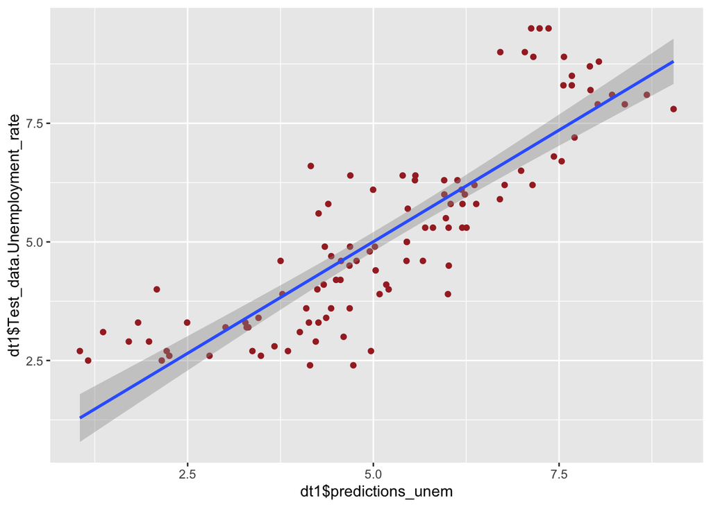

## 7.2 Wages

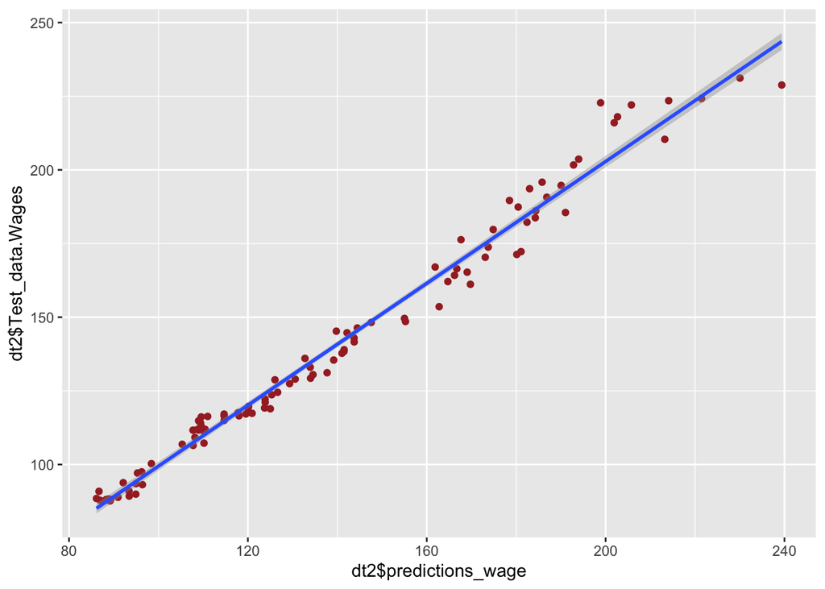

In both plots, the x-axis represents the predicted values, while the y-axis represents the actual values. Each point on the plot represents a single observation in the test data set, and the color of the points is set to brown.

The linear regression lines on each plot provide a visual representation of the strength and direction of the relationship between predicted and actual values. If the points on the plot are tightly clustered around the regression line, this suggests a strong relationship between predicted and actual values. Conversely, if the points are scattered widely around the regression line, this suggests a weak relationship.

Therefore, by analyzing these two scatter plots, we can assess the accuracy of the models in predicting unemployment rates and wages. If the scatter of the points is mostly around the regression line, this suggests that the wages model is making more accurate predictions.

# 8 Proposed Solution

Based on our two model analyses, it is clear that sustainable development measures, such as developing new energy sources and diversifying the energy mix, will benefit the local economy in the long run. To balance population and economic growth with energy demand, Colorado could consider continuing to increase its efforts to encourage the use of a range of renewable energy sources, primarily wind and solar, while reducing its reliance on non-renewable energy sources such as coal and natural gas. The government could reduce costs by subsidizing the cost of new energy for home use or by creating a grid system to improve the efficiency of new energy conversion. At the same time, lowering costs and increasing energy use can also be achieved by providing incentives for renewable energy development and increasing investment in new energy generation infrastructure. In addition, policies aimed at promoting energy efficiency and conservation may help reduce overall energy demand while encouraging the adoption of sustainable energy practices. Overall, Colorado must prioritize sustainability and consider the long-term impacts of energy use on the environment and local economy.

# 9 Reference

|  | website |
| --- | --- |
| 1 | https://www.eia.gov/environment/emissions/state/ |
| 2 | https://www.eia.gov/beta/states/states/co/data/dashboard/renewables |
| 3 | https://fred.stlouisfed.org/series/COWTOT |
| 4 | https://www.eia.gov/state/print.php?sid=CO |
| 5 | https://fred.stlouisfed.org/series/COPOP |
| 6 | https://data.colorado.gov/Energy/Gasoline-Prices-in-Colorado/8pk9-mh2i |
| 7 | https://fred.stlouisfed.org/series/COUR |
| 8 | https://www.eia.gov/beta/states/states/co/overview |